# Ecological Niche

Ecology

The total of the adaptations of an organismic unit.

Author

Affiliation

[Zhehao Hu](https://zzzhehao.github.io)

[Department of Biology, University of Hamburg](https://www.biologie.uni-hamburg.de/en.html)

Published

August 27, 2024

```
ℹ Loading zWeb
```

The total of the adaptations of an organismic unit.

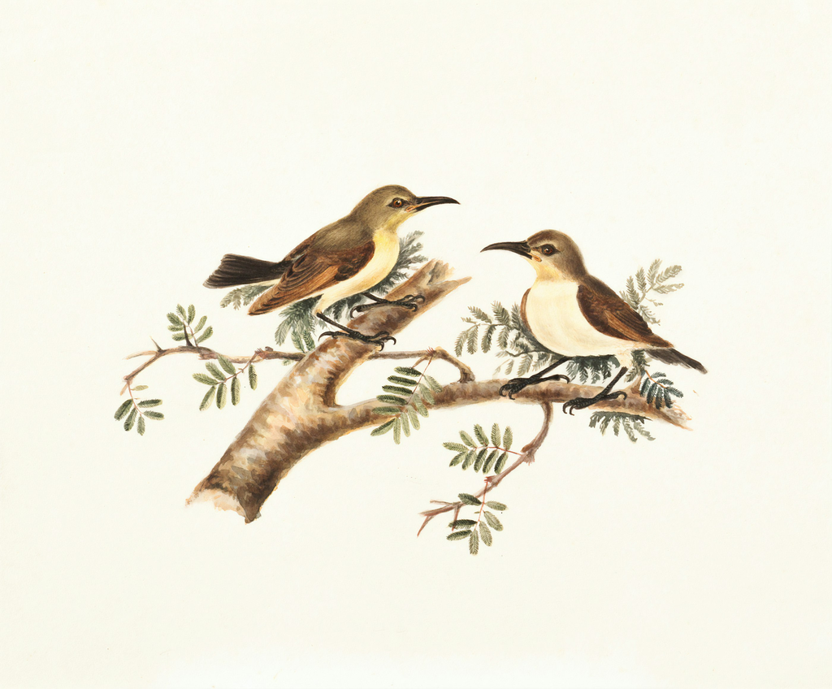

Photo by [McGill Library](https://unsplash.com/@mcgilllibrary?utm_content=creditCopyText&utm_medium=referral&utm_source=unsplash) on [Unsplash](https://unsplash.com/photos/two-brown-and-white-birds-perching-on-tree-branch-illustration-osPrIcTwJy4?utm_content=creditCopyText&utm_medium=referral&utm_source=unsplash)

## Definition

Ecological niche is a term for the position of a species within an ecosystem, describing both the range of conditions necessary for persistence of the species, and its ecological role in the ecosystem.

- Subsumes all of the interactions between a species and the biotic and abiotic environment.
- Effected by food, space, and time.

## Biological Meaning

Data on niches can be used to:

- Make comparisons of the composition and organization of communities.
- Examine shifts in the behavior or ecology of one species in response to another species.
  - Niche shifts are commonly used to study interspecific competition (see Gause’s Principle of Competitive Exclusion)

### Hutchingson’s model of niche as a “*hypervolume*”

Niches can be described or defined by relating **fitness** or **utilization** to environmental variable (abiotic and biotic).

- A range, given the conditions are defined by many axes, which defines the set of conditions under which the animal can survive and reproduce.
- We can easily illustrate a niche described by up to 3 variables (3-D space), but for fourth axes and onward, the result becomes a hypervolume.

**Be aware**:

- not all niche axes are environmental - some niche axes are behaviroal (e.g. noctural vs. diurnal)
- not all axes can be ordered linearly (e.g. types of antipredator behavior)

### Fundamental niche *vs* Realized niche

- **Fundamental niche** (FN) is the entire set of conditions under which an animal (a population, a species) can survive and reproduce.
- **Realized niche** (RN) is the set of condition *actually* used by given animal (a population, a species) after interactions with other species have been taken into account.
- FN ≥ RN
- RN may differ in populations, because of differences in competitors and predators.

### Niche breadth

- **Specialists** have narrow niches, **generalists** have broad niches. These are however relative terms.
- Describes the endpoints of continuous variation in the degree of specialization in resource use, behavior, and physiology.

$$B = \frac{1}{\sum{p_i^2}}$$

- $p_i$ = proportion of individuals that use resource $i$
- Species that use many resources will have large value of $B$, reflecting a generalist pattern of resource use.

#### Between or within phenotypes

- Given known niche breadth of a population, it is however not necessarily clear how individuals within population use resources. There are possibly two patterns:
  - All individuals use entire niche of population, within-phenotype component of niche breadth is large
  - Each individuals uses a narrow part of population’s niche, between-phenotype component of niche breadth is large.
- Individual’s niches may change dramatically during lifetime (e.g. metamorphosis, tadpoles are herbivores, frogs are carnivores)

### Niche overlap

#### Types of overlap

- Coextensive, included, reciprocal overlap, asymmetric overlap
- Non-overlapping: abutting, disjunct

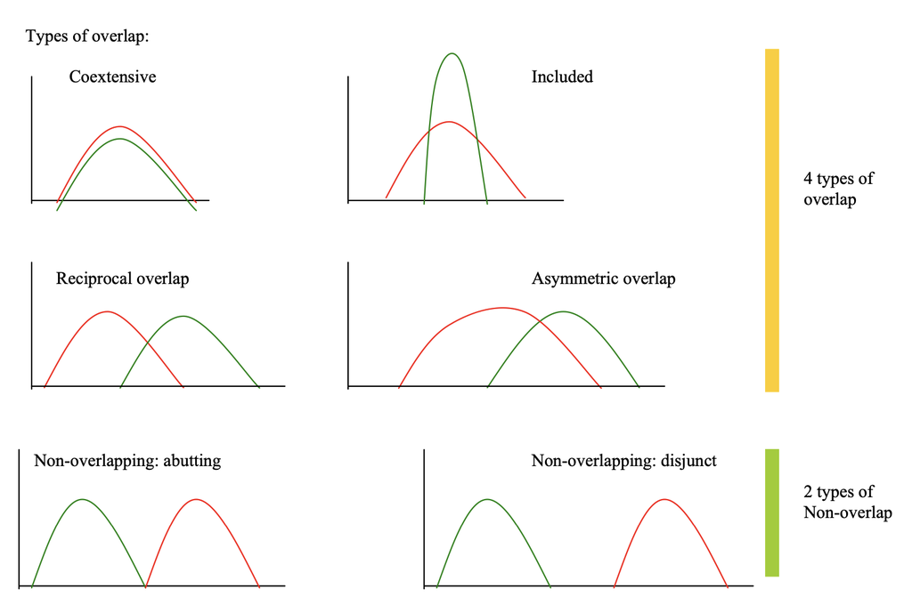

$$D = \frac{r-p}{r+p-2rp}$$

Modification of one presented in MacArthur & Levins (1967).

$$O_{kj} = \frac{\sum p_{ij}p_{ik}}{\sqrt{\sum p^2_{ij}\sum p^2_{ik}}}$$

This formula is symmetric, i.e. $O_{jk} = O_{kj}$ - $P$: proportion of item $i$ used in relation to the total of items used by species $j/k$.

… generate different replicates of a randomized real system (i.e. pseudo-community, the null model) that can be constructed for comparison with an observed prototype.

If say, 95 or 99 of 100 randomized pseudo-communities have mean niche overlaps greater than the observed, results are significant at the P < .05 or P < .01 level, respectively.

Such significance indicates that:

- Observed community exhibits a non-random pattern of resource utilization.
- Species in observed community are utilizing resources in a way that minimized competition.
- Evidence of niche differentiation or resource partitioning among the species in community.
- Evidence for competitive interactions shaping community structure or for past evolutionary adaptations.

4 different algorithm:

[output not shown]

### Use of niches to examine distribution and abundance of species

**List of terms**:

- Interspecific and intraspecific competition
- Niche expansion, niche contraction
- Competitive exclusion
- Character displacement
- Ghost of Competition Past
- Translocation experiments

## Something else to read

- [In Memory of Eric Pianka, “The Lizard Man”: He Thought, He Cared, And He Tried](https://ericpianka.com)

Copyright © 2024 - 2025 Zhehao Hu

E-Mail [LinkedIn](https://www.linkedin.com/in/zhehaohu/) [GitHub](https://github.com/zzzhehao/) [Instagram](https://instagram.com/zhehao.hu_)

Issues on the website? [Report issues](https://github.com/zzzhehao/zzzhehao.github.io/issues). Source code available at [github.com](https://github.com/zzzhehao/zzzhehao.github.io/).